# Responding to a Zoonotic Disease Outbreak - Epidemiological interpretation and implications for decision-making in One Health

Afternoon hands-on tutorial

Published

July 7, 2026

## 1 Overview

We will explore surveillance data from Integrated Bite Case Management (IBCM) in MIMAROPA region. IBCM is a One Health approach to rabies surveillance that links post-exposure vaccination of bite victims, investigation of biting animals, community sensitisation and programmatic coordination, to improve prevention, detection and response. IBCM was introduced to Romblon and Oriental Mindoro provinces in 2020, although COVID-19 restrictions prevented full implementation. In 2022 IBCM expanded to Marinduque province and in 2024 to Occidental Mindoro.

Using these data you will examine where outbreaks occurred; how these outbreaks spread; and why. In groups you will look more deeply into one province and consider the implications for control and prevention.

## 2 Learning objectives

In this session you will:

1. gain understanding of how to **critically interpret epidemiological data** considering a **One Health perspective** and the **quality of evidence**.
2. In so doing you should: **identify gaps in surveillance and control**; and **make recommendations** for future action.

Code is folded but available via the **Show code** button.

**NoteFiles you need (in your workshop folder)**

- `dat_all_anon.csv` — human and animal rabies cases for MIMAROPA
- `mdv_summary.csv` — dog vaccination data (timing of vaccination campaigns in the region by province)
- `rolling_vac_cov_yr.csv` — hupreprocessed estimates of vaccination coverage by municipality
- `PHL_municipality.shp` (and its `.dbf`, `.shx`, `.prj` files) — municipality polygons for MIMAROPA

**Noteimport and process the data for plotting**

```r
library(tidyverse)
library(lubridate)
library(sf)
library(here)
library(reactable)
library(scales)

# Set the province names of interest
province_names <- c("Romblon", "Oriental Mindoro", "Marinduque", "Occidental Mindoro")

## load and process the outbreak data
dat_outbreak <- read_csv(here("data","epi","dat_all_anon.csv"))

head(dat_outbreak) # look to identify what columns are in the data
```

| barangay | municipality | province | case_status | date | case_status_fct | case_type | year | island |
| --- | --- | --- | --- | --- | --- | --- | --- | --- |
| Apitong | Boac | Marinduque | Confirmed | 24/09/2023 | Confirmed (Animal) | Animal | 2023 | Marinduque |
| Balogo | Boac | Marinduque | Confirmed | 10/10/2023 | Confirmed (Animal) | Animal | 2023 | Marinduque |
| Agumaymayan | Boac | Marinduque | Confirmed | 06/10/2023 | Confirmed (Animal) | Animal | 2023 | Marinduque |
| Laylay | Boac | Marinduque | Confirmed | 23/10/2023 | Confirmed (Animal) | Animal | 2023 | Marinduque |
| Bangbangalon | Boac | Marinduque | Probable | 13/10/2023 | Probable (Animal) | Animal | 2023 | Marinduque |
| Bangbangalon | Boac | Marinduque | Probable | 16/10/2023 | Probable (Animal) | Animal | 2023 | Marinduque |

```r
dat_outbreak <- dat_outbreak %>% mutate(date = dmy(date)) # reformat the dates
```

## 3 Describing the outbreak:

### 3.1 Epidemic curve

Monthly reported animal rabies cases (confirmed and probable) and human rabies deaths in Oriental Mindoro, Romblon, Marinduque and Occidental Mindoro are presented in a time series.

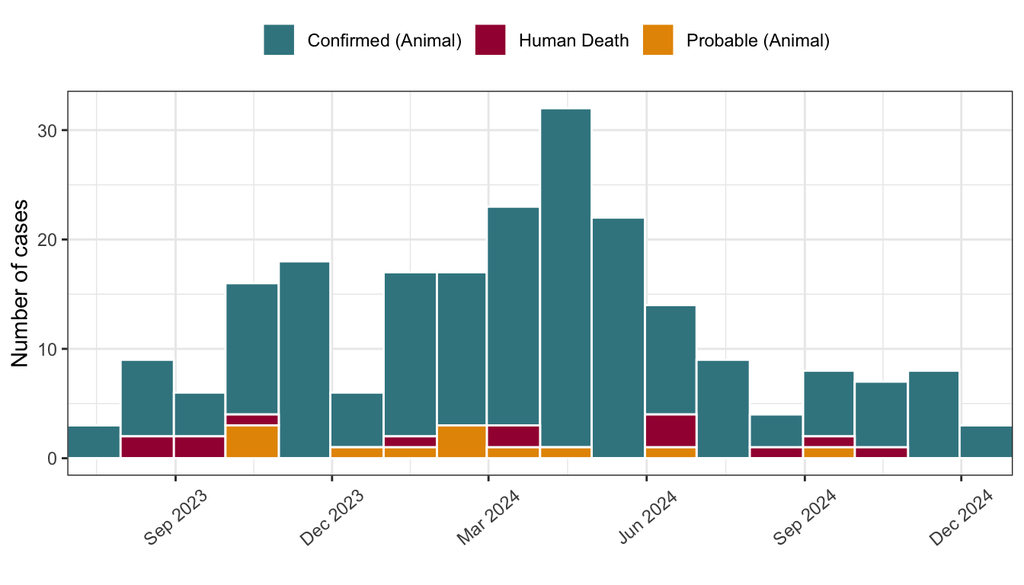

```r
## Filter the outbreak data
dat_outbreak_trun <- dat_outbreak %>%
  filter(date >= "2023-06-30" & date < "2024-12-31") # Work out how to show different time windows

# create monthly breaks for the period of interest
monthly_breaks_trun <- seq.Date(
  from = floor_date(min(dat_outbreak_trun$date, na.rm = TRUE), "month"),
  to   = ceiling_date(max(dat_outbreak_trun$date), "month"),
  by   = "month"
) - 1
# print out this object (monthly_breaks_trun) - is it creating what you want?

# Set the colour palettes used for plots
pal_status <- c("Human Death"        = "#A3003F",
                "Probable (Animal)"  = "#E59500",
                "Confirmed (Animal)" = "#3C8590")

# Now create a timeseries of these data
ggplot(dat_outbreak_trun, # indicate the data you are plotting from
       aes(x = date, fill = case_status_fct)) + # set the x-axis & fill colours for the stacked bars
  geom_histogram(breaks = monthly_breaks_trun, col = "white") + # format histogram with monthly breaks & white borders
  scale_x_date(expand = c(0, 0), date_breaks = "3 months", date_labels = "%b %Y") + # format the x-axis - every 3 months add label for the month and year
  scale_fill_manual(values = pal_status) + # add colours for the different case types
  labs(y = "Number of cases", x = "", fill = "") + # add labels for the y-axis and legend
  theme_bw() + # Use the black and white theme
  theme(axis.text.x  = element_text(angle = 40, vjust = 0.5), # format the x-axis text - angled & vertically justified
        legend.position = "top") # set the legend position to the top of the plot
```

### 3.2 Locations of cases

The spatial distribution of all these cases are mapped. Human deaths are shown as triangles, whilst animal cases are shown as circles.

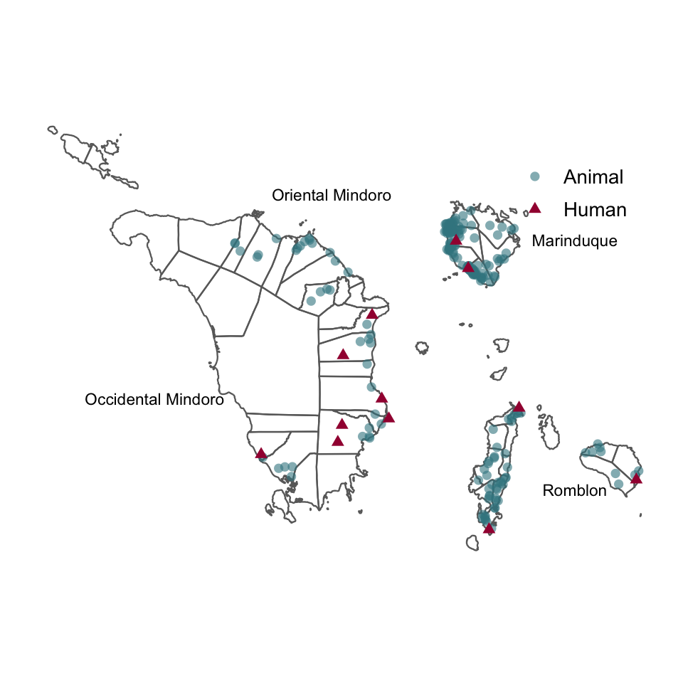

```r
## Geographic data for mapping
municipality <- st_read(here("data", "gis"), layer = "PHL_municipality", quiet = TRUE)
village_loc  <- read.csv(here("data/gis", "PHL_village_centroids.csv"))

# what type of objects are the different municipality and village location files?
# hint - use class() and dim() commands!
# do you know why these objects are so large?

# Attach coordinates
village_loc_filt <- village_loc %>% # filter the village_loc data to only include the provinces of interest
  filter(str_starts(Loc_ID, paste(paste0(province_names, "-"), collapse = "|")))
# this is quite a complex operation! you can explore how it works later, but basically it is filtering the Loc_ID column to only include those that start with the province names of interest

# Now join the coordinates to the outbreak data
dat_mapped <- dat_outbreak_trun %>% # create a new dataframe (dat_mapped) with the outbreak data and coordinates
  mutate(loc_id = paste(province, municipality, barangay, sep = "-")) %>% # create a column (loc_id) that combines the province, municipality and barangay columns
  left_join(select(village_loc_filt, Loc_ID, Latitude, Longitude),
            by = c("loc_id" = "Loc_ID")) # join the datasets (village_loc_filt & the outbreak data) using the loc_id column

municipality_df <- municipality %>%
  filter(NAME_1 %in% province_names) # filter the municipality data to only include the provinces of interest

# Set the colour palette for the case types
pal_type   <- c("Human" = "#A3003F",
                "Animal" = "#3C8590")

# Now create the map
ggplot() + # municipality boundaries in grey outline:
  geom_sf(data = municipality_df, alpha = 0, colour = "dimgrey", linewidth = 0.4) +
  geom_point( # use the dat_mapped dataframe for the points
    data = dat_mapped,
    aes(x = Longitude, y = Latitude, # set x and y coordinates for the human and animal cases
        colour = case_type, shape = case_type, alpha = case_type), # set the colour, shape and transparency attributes for human vs animal cases
    position = position_jitter(h = 0.01, w = 0.01), # add some jitter to avoid overlapping points
    size = 2 # set the size of the points
  ) +
  scale_colour_manual(values = pal_type) +
  scale_shape_manual(values  = c("Human" = 17, "Animal" = 16)) + # set the point shape for human vs animal cases (triangle, circle)
  scale_alpha_manual(values  = c("Human" = 1,  "Animal" = 0.6)) + # set the transparency for human vs animal cases
  labs(colour = "", shape = "", alpha = "") +
  # annotate province names manually (you may want to do this for other settings too!)
  annotate("text", x = c(122.4,122.4,121.3,120.5), # define x,y coordinates and add text labels
           y = c(12.3,13.4,13.6,12.7),
           label = c("Romblon","Marinduque","Oriental Mindoro","Occidental Mindoro"),
           size = c(3,3,3,3)) +
  theme_minimal(base_size = 13) +
  theme(legend.position  = "inside", legend.position.inside = c(0.85, 0.85),
        panel.grid.major = element_blank(),
        axis.text        = element_blank(),
        axis.title       = element_blank())
```

### 3.3 Take a closer look at the extended epidemic curve(s) for the region

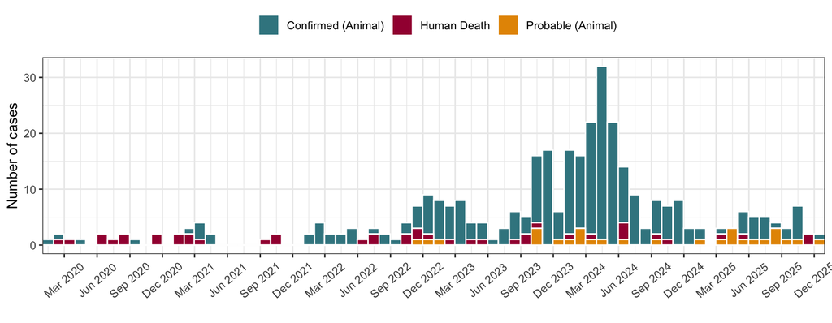

```r
# Filter out Occidental Mindoro province and focus on the 3 provinces with IBCM in place since 2020
dat_outbreak_provinces <- dat_outbreak %>%
  filter(province != "Occidental Mindoro") %>%
  filter(date >= ymd("2020-01-01") & date <= ymd("2026-01-01"))

monthly_breaks <- seq.Date(
  from = floor_date(min(dat_outbreak_provinces$date, na.rm = TRUE), "month"),
  to   = ceiling_date(max(dat_outbreak_provinces$date), "month"),
  by   = "month"
) - 1

# Now create the epidemic curve for the full period
ggplot(dat_outbreak_provinces, aes(x = date, fill = case_status_fct)) +
  geom_histogram(breaks = monthly_breaks, col = "white") +
  scale_x_date(expand = c(0, 0), date_breaks = "3 months", date_labels = "%b %Y") +
  scale_fill_manual(values = pal_status) +
  labs(y = "Number of cases", x = "", fill = "") +
  theme_bw() +
  theme(axis.text.x     = element_text(angle = 40, vjust = 0.5),
        legend.position = "top")
```

### 3.4 Plot the epidemic curve by province

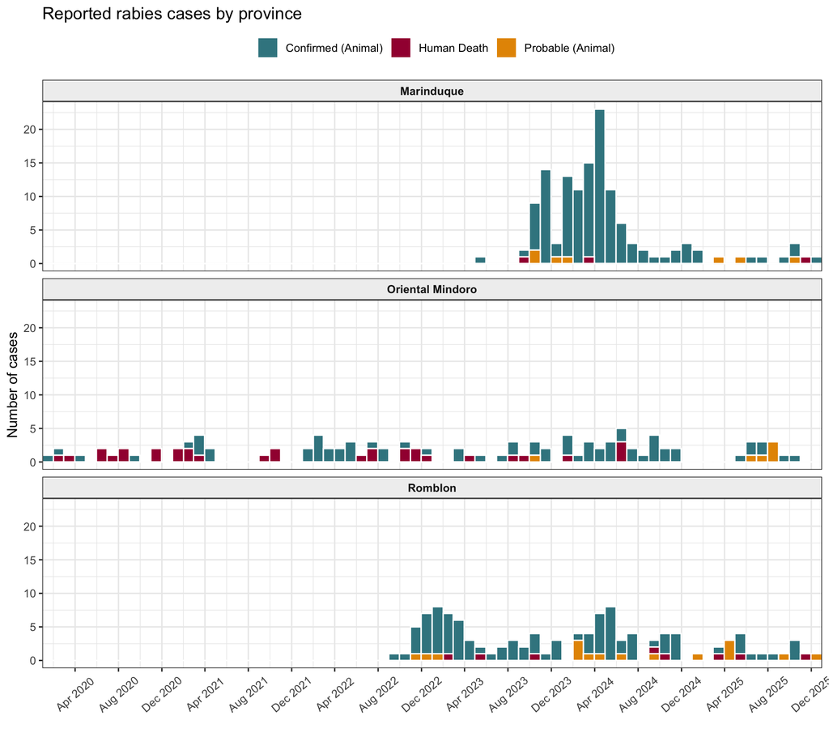

```r
# Now create the epidemic curve for the full outbreak data and *facet* by province
ggplot(dat_outbreak_provinces, aes(x = date, fill = case_status_fct)) +
  geom_histogram(breaks = monthly_breaks, col = "white") +
  scale_x_date(expand = c(0, 0), date_breaks = "4 months", date_labels = "%b %Y") +
  scale_fill_manual(values = pal_status) +
  facet_wrap(~province, ncol = 1) + # facet by province and arrange in 1 column
  labs(y = "Number of cases", x = "", fill = "",
       title = "Reported rabies cases by province") +
  theme_bw() +
  theme(axis.text.x     = element_text(angle = 40, vjust = 0.5),
        legend.position = "top",
        strip.background = element_rect(fill = "#f0f0f0"),
        strip.text       = element_text(face = "bold"))
```

### 3.5 Look at the locations of cases across the years

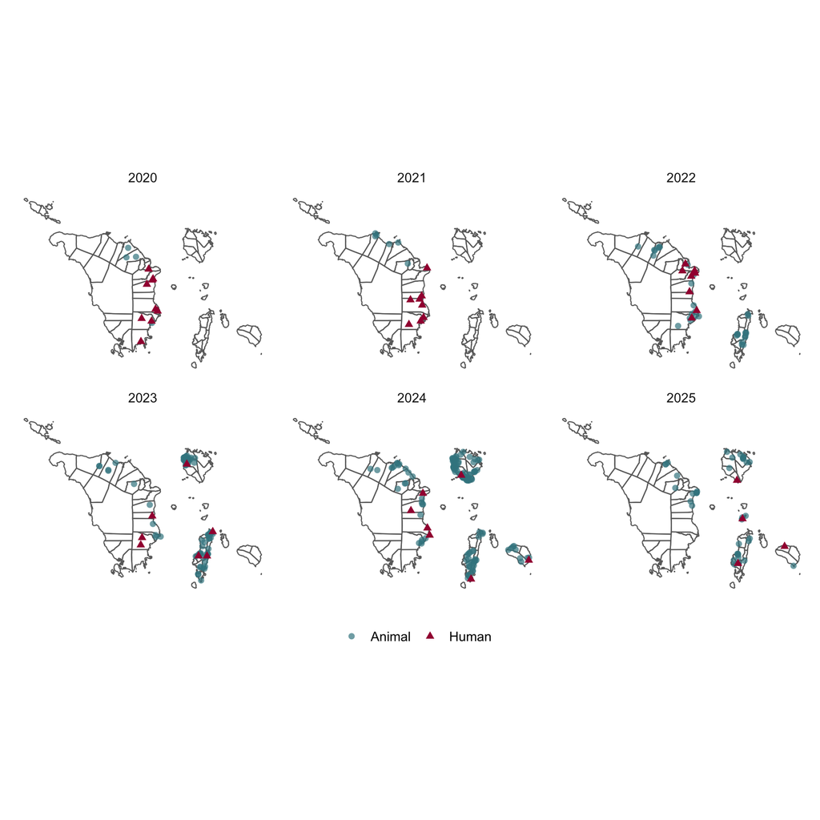

```r
# Attach coordinates
village_loc_filt <- village_loc %>%
  filter(str_starts(Loc_ID, paste(paste0(province_names, "-"), collapse = "|")))

# Now join the coordinates to the outbreak data
dat_mapped <- dat_outbreak_provinces %>%
  mutate(loc_id = paste(province, municipality, barangay, sep = "-")) %>%
  left_join(select(village_loc_filt, Loc_ID, Latitude, Longitude),
            by = c("loc_id" = "Loc_ID"))

# Filter municipality data for the provinces of interest
municipality_df <- municipality %>%
  filter(NAME_1 %in% province_names)

# Now create the map of cases for the provinces of interest
ggplot() +
  geom_sf(data = municipality_df, alpha = 0, colour = "dimgrey", linewidth = 0.4) +
  # add points for human and animal cases with jitter to avoid overlap
  geom_point(
    data = dat_mapped,
    aes(x = Longitude, y = Latitude,
        colour = case_type, shape = case_type, alpha = case_type),
    position = position_jitter(h = 0.01, w = 0.01),
    size = 2
  ) +
    facet_wrap(~ year) + # make a map for every year
  scale_colour_manual(values = pal_type) +
  scale_shape_manual(values  = c("Human" = 17, "Animal" = 16)) +
  scale_alpha_manual(values  = c("Human" = 1,  "Animal" = 0.7)) +
  labs(colour = "", shape = "", alpha = "") +
  theme_minimal(base_size = 13) +
  theme(legend.position  = "bottom",
        panel.grid.major = element_blank(),
        axis.text        = element_blank(),
        axis.title       = element_blank())
```

## 4 How did the epidemiological situation evolve in each province?

Looking at the epidemic curve by province reveals whether provinces were affected simultaneously or sequentially — this is important for understanding routes of disease spread and the timing of introduction events

**TipUsing your R skills work through the data in your Provincial groups!**

Add the data on mass dog vaccination campaigns to help with your interpretation

```r
# Import the mdv data sets
mdv_summary <- read.csv(here("data", "epi", "mdv_summary.csv"))
mdv_rolling  <- read_csv(here("data", "epi", "rolling_vac_cov_yr.csv"))
```

### 4.1 Oriental Mindoro

> **Key questions and things to explore:**
> - What is happening in the early outbreak period?
> - How do animal cases compare to human cases in Oriental Mindoro?
> - Roughly 1 person is bitten every 3 rabid dogs. Of people bitten, 90% get PEP. Of the 10% that don’t get PEP, 20% will develop rabies and die. How does this change your interpretation of the early outbreak period?
> - How does the most recent human death in April 2026 (look at the 2026 map!) change your interpretation of what is happening in Oriental Mindoro?

#### 4.1.1 How do human cases compare to animal cases in Oriental Mindoro?

You will need to filter the outbreak data for Oriental Mindoro province and use the facet command to split these data according to human and animal cases.

**TipShow solution**

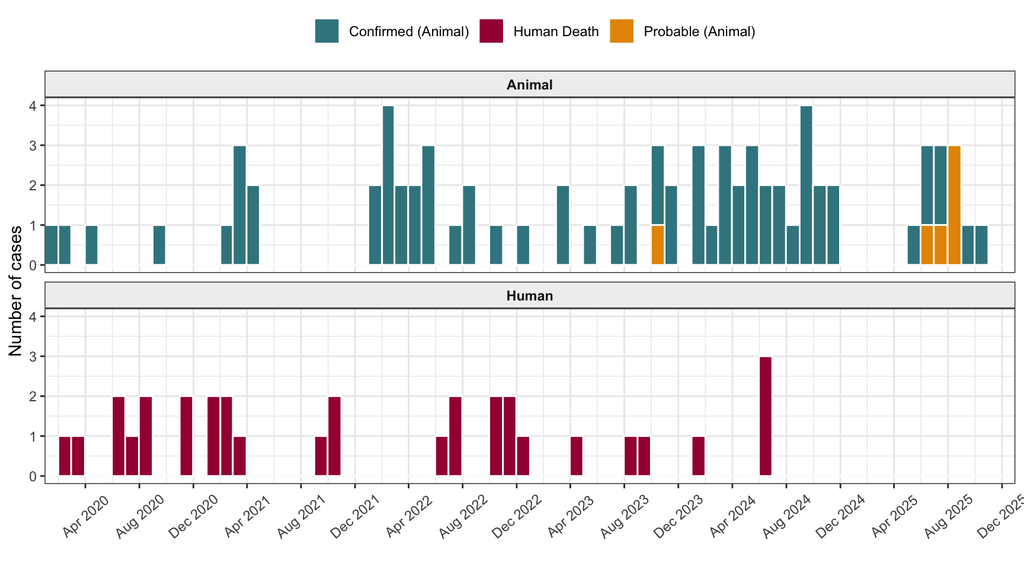

```r
# Filter outbreak data for Oriental Mindoro and create a histogram of cases with monthly breaks and white borders,
# facet by case type (human or animal)
dat_outbreak_provinces %>%
  filter(province == "Oriental Mindoro") %>%
ggplot(aes(x = date, fill = case_status_fct)) +
  geom_histogram(breaks = monthly_breaks, col = "white") +
  scale_x_date(expand = c(0, 0), date_breaks = "4 months", date_labels = "%b %Y") +
  scale_fill_manual(values = pal_status) +
  facet_wrap(~case_type, ncol = 1) +
  labs(y = "Number of cases", x = "", fill = "") +
  theme_bw() +
  theme(axis.text.x     = element_text(angle = 40, vjust = 0.5),
        legend.position = "top",
        strip.background = element_rect(fill = "#f0f0f0"),
        strip.text       = element_text(face = "bold"))
```

#### 4.1.2 What impact do you think the mass dog vaccination campaigns had on rabies transmission?

Overlay the mass dog vaccination data to the timeseries plot. The mass dog vaccination data will need filtering too!

**TipShow solution**

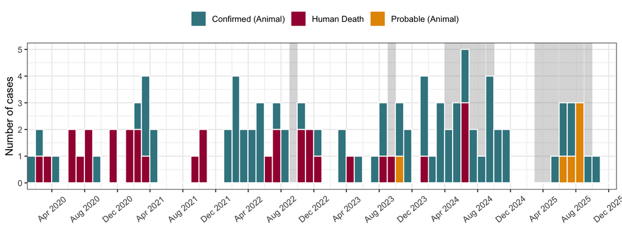

```r
# Filter MDV data for Oriental Mindoro and create a date column
mdv_ormin <- mdv_summary %>%
  filter(region == "Ormin") %>%
  mutate(
    date_start = dmy(paste("01", month, year)),
    date_end   = date_start + days(30)
  )

# Filter outbreak data for Oriental Mindoro
dat_outbreak_provinces %>%
  filter(province == "Oriental Mindoro") %>%
  ggplot(aes(x = date, fill = case_status_fct)) + # stacked barplot with date on x-axis and colour based on case status
  # add rectangles to indicate the timing of mass dog vaccination campaigns
  geom_rect(
    data = mdv_ormin,
    aes(xmin = date_start, xmax = date_end, ymin = 0, ymax = Inf, fill = "grey70"),
    inherit.aes = FALSE,
    alpha = 0.3
  ) +
  # add histogram of cases with monthly breaks and white borders
  geom_histogram(breaks = monthly_breaks, col = "white") +
  scale_x_date(expand = c(0, 0), date_breaks = "4 months", date_labels = "%b %Y") +
  scale_fill_manual(values = c(pal_status)) +
  # add labels for the y-axis, x-axis and legend
  labs(y = "Number of cases", x = "", fill = "") +
  theme_bw() +
  theme(
    axis.text.x      = element_text(angle = 40, vjust = 0.5),
    legend.position  = "top",
    strip.background = element_rect(fill = "#f0f0f0"),
    strip.text       = element_text(face = "bold")
  )
```

#### 4.1.3 Does the distribution of cases over time and across municipalities suggest any gaps in surveillance (from the health or animal health perspective)?

Try joining the Oriental mindoro data with municipality vaccination data - it is a little bit tricky!

**TipShow solution**

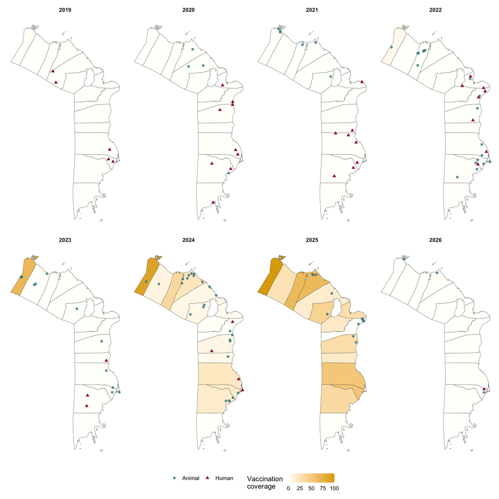

```r
# Attach coordinates to outbreak data for Oriental Mindoro
dat_mapped <- dat_outbreak %>%
  mutate(
    loc_id = paste(province, municipality, barangay, sep = "-"),
    year   = lubridate::year(date)
  ) %>%
  filter(province == "Oriental Mindoro") %>%
  left_join(
    select(village_loc, Loc_ID, Latitude, Longitude),
    by = c("loc_id" = "Loc_ID")
  )

# Filter municipality data for Oriental Mindoro and join with vaccination coverage data
municipality_df <- municipality %>%
  filter(NAME_1 == "Oriental Mindoro") %>%
  left_join(mdv_rolling, by = c("NAME_2" = "municipality")) %>%
  filter(NAME_2 != "Naujan Lake") ## Removing water body which was causing NA

# Now create the map of cases and vaccination coverage
ggplot() +
  # add municipality polygons with fill colour based on vaccination coverage
  geom_sf(data = municipality_df, aes(fill = vacc_cov_roll * 100), alpha = 80) +
      scale_fill_gradient(
      name   = "Vaccination \ncoverage",
      low    = "#FFFFFB", high = "#DFA801",
      labels = comma, limits = c(0, 100)
    ) +
  # add points for human and animal cases with jitter to avoid overlap
  geom_point(
    data = dat_mapped,
    aes(x = Longitude, y = Latitude,
        colour = case_type, shape = case_type, alpha = case_type),
    position = position_jitter(h = 0.01, w = 0.01),
    size = 2
  ) +
  scale_colour_manual(values = pal_type) +
  scale_shape_manual(values  = c("Human" = 17, "Animal" = 16)) +
  scale_alpha_manual(values  = c("Human" = 1,  "Animal" = 0.8)) +
  facet_wrap(~ year,ncol=4) +
  labs(
    colour = "", shape = "", alpha = "" ) +
  theme_minimal(base_size = 13) +
  theme(
    legend.position  = "bottom",
    panel.grid.major = element_blank(),
    axis.text        = element_blank(),
    axis.title       = element_blank(),
    strip.text       = element_text(face = "bold")
  )
```

*Note: some vaccination has occurred in 2026, however this data has not yet been released*

### 4.2 Romblon

> **Key questions and things to consider:**
> - Romblon province is made up of different islands. How did rabies spread across the islands over time?
> - If you were facing the situation in Tablas island in December 2022 (look at the 2022 map), what actions would you recommend to the local authorities?
> - When did the first death occur? What can you say about the responsiveness of dog vaccination efforts?
> - What if you were facing the situation in Sibuyan island in December 2023, would you be concerned? what communications would you want between municipalities? How might your thinking change by August 2024? Do you have any concerns if you are from Corcuera island? What do these complete plots tell you about the current surveillance efforts in Romblon?

#### 4.2.1 How does the outbreak look in Romblon if we break this down by island?

You will need to filter the outbreak data to Romblon Province. Overlay the mass dog vaccination data to the timeseries plot. The mass dog vaccination data will need filtering too!

**TipShow solution**

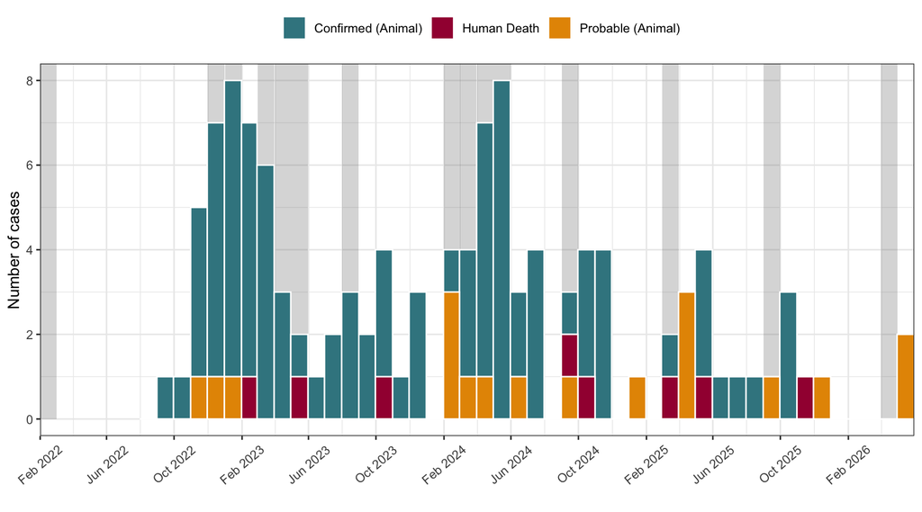

```r
# Filter outbreak data for Romblon and create a histogram of cases with monthly breaks and white borders, facet by island
dat_romblon = dat_outbreak %>%
  filter(province == "Romblon")

# Create monthly breaks for Romblon outbreak data
monthly_breaks <- seq.Date(
  from = floor_date(min(dat_romblon$date - 60, na.rm = TRUE), "month"),
  to   = ceiling_date(max(dat_romblon$date), "month"),
  by   = "month"
) - 1

# Filter MDV data for Romblon and create date columns for the start and end of each campaign
mdv_romblon <- mdv_summary %>%
  filter(region == "Romblon") %>%
  mutate(
    date_start = dmy(paste("01", month, year)),
    date_end   = date_start + days(30)
  )

# Now create the epidemic curve for Romblon with rectangles indicating the timing of mass dog vaccination campaigns
dat_romblon %>%
ggplot(aes(x = date, fill = case_status_fct)) +
  # add rectangles to indicate the timing of mass dog vaccination campaigns
    geom_rect(
    data = mdv_romblon,
    aes(xmin = date_start, xmax = date_end, ymin = 0, ymax = Inf, fill = "grey70"),
    inherit.aes = FALSE,
    alpha = 0.3
  ) +
  # add histogram of cases with monthly breaks and white borders
  geom_histogram(breaks = monthly_breaks, col = "white") +
  scale_x_date(expand = c(0, 0), date_breaks = "4 months", date_labels = "%b %Y") +
  scale_fill_manual(values = pal_status) +
  labs(y = "Number of cases", x = "", fill = "") +
  theme_bw() +
  theme(axis.text.x     = element_text(angle = 40, vjust = 0.5),
        legend.position = "top",
        strip.background = element_rect(fill = "#f0f0f0"),
        strip.text       = element_text(face = "bold"))
```

*Dates of mass dog vaccination campaigns are shown in grey (MDV campaign defined as >700 dogs vaccinated in a municipality in a month)*

#### 4.2.2 Can you show the epidemic curves for each of Romblon’s islands?

Use the facet command to split up the data by island

**TipShow solution**

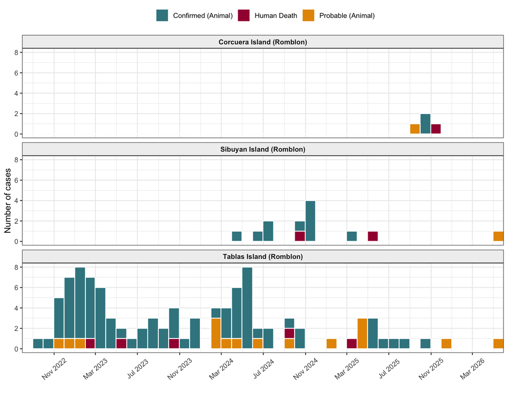

```r
# Now create the epidemic curve for Romblon with rectangles indicating the timing of mass dog vaccination campaigns,
# facet by island
dat_romblon %>%
ggplot(aes(x = date, fill = case_status_fct)) +
  geom_histogram(breaks = monthly_breaks, col = "white") +
  scale_x_date(expand = c(0, 0), date_breaks = "4 months", date_labels = "%b %Y") +
  scale_fill_manual(values = pal_status) +
  facet_wrap(~island, ncol = 1) +
  labs(y = "Number of cases", x = "", fill = "") +
  theme_bw() +
  theme(axis.text.x     = element_text(angle = 40, vjust = 0.5),
        legend.position = "top",
        strip.background = element_rect(fill = "#f0f0f0"),
        strip.text       = element_text(face = "bold"))
```

#### 4.2.3 What does the spatiotemporal distribution of these cases suggest about how rabies spread across the province?

Try mapping these cases by year. Use facet_wrap again! The islands of interest are Tablas, Sibuyan and Corcuera. You’ll need to look at the maps to think about where to put the island labels! Start by mapping the municipality dataframe to show the vaccination coverage across the municipalities. This is a bit tricky.

**TipShow solution**

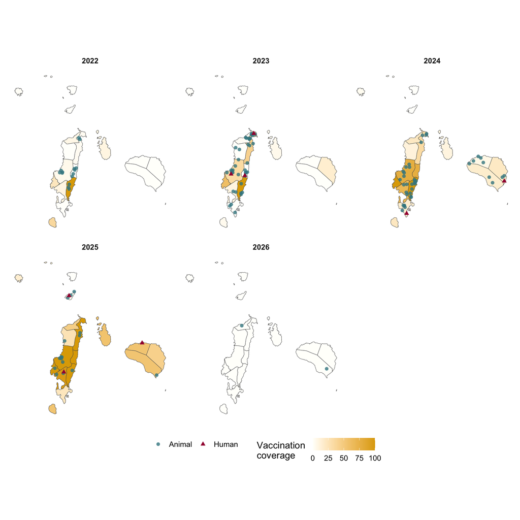

```r
# Attach coordinates to outbreak data for Romblon
dat_mapped <- dat_outbreak %>%
  mutate(
    loc_id = paste(province, municipality, barangay, sep = "-"),
    year   = lubridate::year(date)
  ) %>%
  filter(province == "Romblon") %>%
  left_join(
    select(village_loc, Loc_ID, Latitude, Longitude),
    by = c("loc_id" = "Loc_ID")
  )

# Filter municipality data for Romblon and join with vaccination coverage data
municipality_df <- municipality %>%
  filter(NAME_1 == "Romblon") %>%
  left_join(mdv_rolling, by = c("NAME_2" = "municipality")) %>%
  filter(year >= 2022) ## filtering as no cases in Romblon until 2022

# Now create the map of cases and vaccination coverage for Romblon
ggplot() +
  geom_sf(data = municipality_df, aes(fill = vacc_cov_roll * 100), alpha = 80) +
      scale_fill_gradient(
      name   = "Vaccination \ncoverage",
      low    = "#FFFFFB", high = "#DFA801",
      labels = comma, limits = c(0, 100)
    ) +
  # add points for human and animal cases with jitter to avoid overlap
  geom_point(
    data = dat_mapped,
    aes(x = Longitude, y = Latitude,
        colour = case_type, shape = case_type, alpha = case_type),
    position = position_jitter(h = 0.01, w = 0.01),
    size = 2
  ) +
  scale_colour_manual(values = pal_type) +
  scale_shape_manual(values  = c("Human" = 17, "Animal" = 16)) +
  scale_alpha_manual(values  = c("Human" = 1,  "Animal" = 0.8)) +
  facet_wrap(~ year) +

  # # annotate provinces manually as the labels are not in the shapefile
  # annotate("text", x = c(122.2), y = c(12.3), label = c("Tablas"), size = c(3)) +
  # annotate("text", x = c(122.6), y = c(12.55), label = c("Sibuyan"), size = c(3)) +
  # annotate("text", x = c(122.2), y = c(12.8), label = c("Corcuera"), size = c(3)) +

  labs(
    colour = "", shape = "", alpha = "" ) +
  theme_minimal(base_size = 13) +
  theme(
    legend.position  = "bottom",
    panel.grid.major = element_blank(),
    axis.text        = element_blank(),
    axis.title       = element_blank(),
    strip.text       = element_text(face = "bold")
  )
```

*Note: some vaccination has occurred in 2026, however this data has not yet been released*

### 4.3 Marinduque

> **Key questions and things to consider:**
> - How did the outbreak evolve in Marinduque over time?
> - What do these plots tell you about the current surveillance efforts in Marinduque?
> - When did the first death occur? And how does this correspond to the increase in dog vaccination efforts?
> - How does the outbreak in Marinduque compare to the outbreaks in Oriental mindoro and Romblon provinces?
> - How does the human death in Dec 2025 impact your interpretation?

#### 4.3.1 What impact do you think the mass dog vaccination campaigns had on rabies transmission?

You will need to filter the outbreak data to Marinduque Province. Overlay the mass dog vaccination data to the timeseries plot. The mass dog vaccination data will need filtering too!

**TipShow solution**

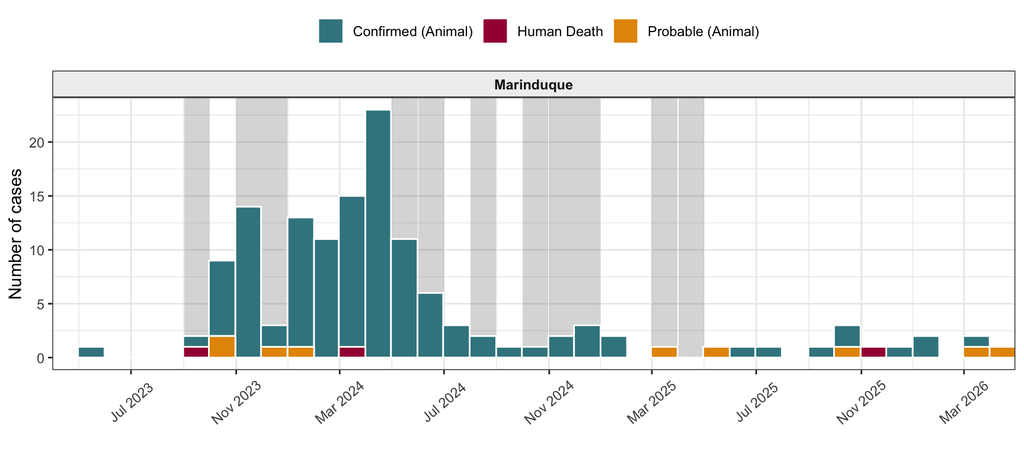

```r
# Filter MDV data for Marinduque and create date column
mdv_marin <- mdv_summary %>%
  filter(region == "Marinduque") %>%
  mutate(
    date_start = dmy(paste("01", month, year)),
    date_end   = date_start + days(30)
  )

# Filter outbreak data for Marinduque
dat_marin = dat_outbreak %>%
  filter(province == "Marinduque")

# Create monthly breaks for Marinduque outbreak data
monthly_breaks <- seq.Date(
  from = floor_date(min(dat_marin$date - 60, na.rm = TRUE), "month"),
  to   = ceiling_date(max(dat_marin$date), "month"),
  by   = "month"
) - 1

# Now create the epidemic curve for Marinduque with rectangles indicating the timing of mass dog vaccination campaigns
dat_outbreak %>%
  filter(province == "Marinduque") %>%
ggplot(aes(x = date, fill = case_status_fct)) +
  # add rectangles to indicate the timing of mass dog vaccination campaigns
  geom_rect(
    data = mdv_marin,
    aes(xmin = date_start, xmax = date_end, ymin = 0, ymax = Inf, fill = "grey70"),
    inherit.aes = FALSE,
    alpha = 0.3
  ) +
  # add histogram of cases with monthly breaks and white borders
  geom_histogram(breaks = monthly_breaks, col = "white") +
  scale_x_date(expand = c(0, 0), date_breaks = "4 months", date_labels = "%b %Y") +
  scale_fill_manual(values = pal_status) +
  facet_wrap(~island, ncol = 1) +
  labs(y = "Number of cases", x = "", fill = "") +
  theme_bw() +
  theme(axis.text.x     = element_text(angle = 40, vjust = 0.5),
        legend.position = "top",
        strip.background = element_rect(fill = "#f0f0f0"),
        strip.text       = element_text(face = "bold"))
```

*Dates of mass dog vaccination campaigns are shown in grey (a campaign defined as >700 dogs vaccinated in a municipality in a month)*

#### 4.3.2 What do you think the prospects are for Marinduque eliminating rabies from the province?

Try mapping these cases by year. Use facet_wrap again! Start by mapping the municipality dataframe to show the vaccination coverage across the municipalities. This is a bit tricky.

Elimination requires interruption of rabies transmission in domestic dogs. What do you think about the quality of rabies surveillance on Marinduque? Can you be confident that when you are no longer seeing dog rabies cases, that rabies has been eliminated? or do you think that an absence of detected rabies cases just reflects weak surveillance? Also remember that the incubation period for rabies is on average around one month, but can sometimes be several months long. What does this mean for being confident that rabies has gone?

**TipShow solution**

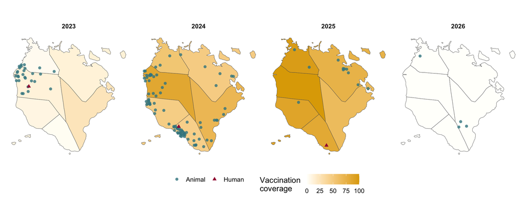

```r
# Attach coordinates to outbreak data for Marinduque
dat_mapped <- dat_outbreak %>%
  mutate(
    loc_id = paste(province, municipality, barangay, sep = "-"),
    year   = lubridate::year(date)
  ) %>%
  filter(province == "Marinduque") %>%
  left_join(
    select(village_loc, Loc_ID, Latitude, Longitude),
    by = c("loc_id" = "Loc_ID")
  )

# Filter municipality data for Marinduque and join with vaccination coverage data
municipality_df <- municipality %>%
  filter(NAME_1 == "Marinduque") %>%
  left_join(mdv_rolling, by = c("NAME_2" = "municipality")) %>%
  filter(year >= 2023) ## filtering as no cases in Marinduque until 2022

# Now create the map of cases and vaccination coverage for Marinduque
ggplot() +
  # add municipality polygons with fill colour based on vaccination coverage
  geom_sf(data = municipality_df, aes(fill = vacc_cov_roll * 100), alpha = 80) +
      scale_fill_gradient(
      name   = "Vaccination \ncoverage",
      low    = "#FFFFFB", high = "#DFA801",
      labels = comma, limits = c(0, 100)
    ) +
  # add points for human and animal cases with jitter to avoid overlap
  geom_point(
    data = dat_mapped,
    aes(x = Longitude, y = Latitude,
        colour = case_type, shape = case_type, alpha = case_type),
    position = position_jitter(h = 0.01, w = 0.01),
    size = 2
  ) +
  scale_colour_manual(values = pal_type) +
  scale_shape_manual(values  = c("Human" = 17, "Animal" = 16)) +
  scale_alpha_manual(values  = c("Human" = 1,  "Animal" = 0.8)) +
  facet_wrap(~ year, ncol = 4) + # make a map for every year and arrange them in columns - there are 4 years of cases
  labs(
    colour = "", shape = "", alpha = "" ) +
  theme_minimal(base_size = 13) +
  theme(
    legend.position  = "bottom",
    panel.grid.major = element_blank(),
    axis.text        = element_blank(),
    axis.title       = element_blank(),
    strip.text       = element_text(face = "bold")
  )
```

*Note: some vaccination has occurred in 2026, however this data has not yet been released*

## 5 Now lets think about what all this means across the MIMAROPA region

**TipSome useful background!**

Rabies is spread by the bite of an infected rabid animal and is **invariably** fatal! This is why post-exposure vaccination (PEP) is needed immediately after a rabid dog bite. If a bite victim only attends a hospital after showing signs of rabies it is too late. But only *around one in 5 rabid dog bite victims will develop rabies* if unvaccinated. So for every unlucky rabies patient, four other rabid bite victims will get lucky and survive without developing rabies.

Usually only around one in 3 rabid dogs bite people; a few of these will bite a lot, but many will bite 1 or 2 people. Remember that surveillance only ever provides a partial picture, of the cases observed or confirmed through sample collection, laboratory testing and official reporting. Can you think of reasons why rabid dogs may not be counted? and what about human rabies cases?

> **Key questions and things to explore:**
> - Which province do you think has the most robust surveillance? (consider surveillance from the veterinary perspective, the public health perspective and under a One Health approach)
> - Do you consider rabies to be endemic in any of the provinces?
> - What do you think are the triggers of outbreak responses?
> - Why do the ratios of human to animal cases differ in the three provinces?

### 5.1 How do human deaths compare with animal cases?

A critical question is whether surveillance is sufficient. If we have areas where human deaths occur with relatively few reported animal cases this would suggest under-reporting of animal cases. Therefore, the annual incidence and the ratio of human deaths to animal cases may provide an indication of the surveillance sensitivity and reporting. Try working through the rest of this optional code and see what you learn in the process:

#### 5.1.1 Ratio of human deaths to animal cases

Calculate the ratios of human deaths to animal cases across the provinces? What do these suggest about how the quality of surveillance varies across the different provinces?

**TipShow solution**

```r
# Create an object for tabulating the province data by animal cases and human deaths
tbl_ratio <- dat_outbreak_provinces %>%
  group_by(province) %>%
  summarise(
    Animal_cases  = sum(case_type == "Animal"),
    Human_deaths  = sum(case_type == "Human"),
    .groups = "drop"
  ) %>%
  mutate(Deaths_per_100_animal = round(Human_deaths / Animal_cases * 100, 1)) %>%
  rename(Province               = province,
         `Animal cases`         = Animal_cases,
         `Human deaths`         = Human_deaths,
         `Deaths per 100 animal cases` = Deaths_per_100_animal)

# This code creates a table for either the html or pdf outputs - its not necessary for your calculations though:
if (knitr::is_html_output()) {
  reactable(tbl_ratio, striped = TRUE, highlight = TRUE, pagination = FALSE)
} else { knitr::kable(tbl_ratio) }
```

| Province | Animal cases | Human deaths | Deaths per 100 animal cases |
| --- | --- | --- | --- |
| Marinduque | 129 | 3 | 2.3 |
| Oriental Mindoro | 76 | 32 | 42.1 |
| Romblon | 108 | 8 | 7.4 |

### 5.2 Is rabies an emerging infectious disease threat or a neglected disease of poverty?

Rabies can be viewed as an emerging disease that can cause outbreaks in areas where it was previously absent. But it is also a disease that is entirely vaccine-preventable, that can be eliminated through dog vaccination, whilst human deaths only occur if people at-risk do not access emergency life-saving vaccines after an exposure.

The last decade in MIMAROPA region illustrates all of these different situations. Can you quantify the incidence of human rabies deaths and of rabies in dogs in each province and how this varies by year? What is the highest incidence? and what is the lowest incidence? Taking these extremes, and extrapolating to the entirety of the Philippines, what is the worst case scenario? how many rabies deaths *could* occur across the country if they were all to face the same challenges in rabies control and prevention?

And what if rabies control improved and surveillance was better - what is the best case scenario? What are the obstacles to achieving this best case outcome? and what can be done better that can support the best outcome?!

#### 5.2.1 Population estimates by province

[output not shown]

#### 5.2.2 Incidence of human deaths and animal cases

Calculate the annual incidence of human deaths and animal cases by province.

**TipShow solution**

```r
# Population data by province
dog_pop <- c(
  "Oriental Mindoro"  = 200000,
  "Occidental Mindoro" = 110000,
  "Marinduque"        = 40000,
  "Romblon"           = 55800   # 30000 + 15000 + 2000 + 8800
)

human_pop <- c(
  "Oriental Mindoro"  = 920000,
  "Occidental Mindoro" = 510000,
  "Marinduque"        = 220000,
  "Romblon"           = 284000  # 170000 + 65000 + 9000 + 40000
)

dat_outbreak <- dat_outbreak %>%
  mutate(years = as.numeric(max(date, na.rm = TRUE) -
                            min(date, na.rm = TRUE)) / 365.25)

# Summary by province
province_summary <- dat_outbreak %>%
  mutate(year = lubridate::year(date)) %>%
  group_by(province) %>%
  summarise(
    animal_cases = sum(case_type == "Animal"),
    human_deaths = sum(case_type == "Human"),
    years        = first(years),
    dogs         = dog_pop[first(province)],
    humans       = human_pop[first(province)],
    .groups = "drop"
  ) %>%
  mutate(
    animal_incidence = round(animal_cases / (dogs * years) * 1000, 2),
    human_incidence  = round(human_deaths / (humans * years) * 100000, 2)
  )

# Overall row
overall_row <- dat_outbreak %>%
  summarise(
    province     = "Overall",
    animal_cases = sum(case_type == "Animal"),
    human_deaths = sum(case_type == "Human"),
    years        = first(years),
    dogs         = sum(unique(dog_pop)),
    humans       = sum(unique(human_pop)),
    animal_incidence = round(animal_cases / (dogs * years) * 1000, 2),
    human_incidence  = round(human_deaths / (humans * years) * 100000, 2)
  )

# Worst case: highest human incidence in any single year + province
worst_case <- dat_outbreak %>%
  mutate(year = lubridate::year(date)) %>%
  group_by(province, year) %>%
  summarise(
    human_deaths = sum(case_type == "Human"),
    .groups = "drop"
  ) %>%
  mutate(
    humans = human_pop[province],
    human_incidence = round(human_deaths / humans * 100000, 2)
  ) %>%
  slice_max(human_incidence, n = 1)


# Bind and display
tbl <- bind_rows(province_summary, overall_row)

tbl_incidence <- tbl %>%
  select(
    Province                                      = province,
    `Animal cases`                                = animal_cases,
    `Animal incidence (per 1,000 dogs/year)`      = animal_incidence,
    `Human deaths`                                = human_deaths,
    `Human incidence (per 100,000 people/year)`   = human_incidence
  )

if (knitr::is_html_output()) {
  reactable(
    tbl_incidence,
    striped = TRUE,
    highlight = TRUE,
    pagination = FALSE,
    rowStyle = function(index) {
      if (tbl$province[index] == "Overall") list(fontWeight = "bold")
    }
  )
} else {
  knitr::kable(tbl_incidence)
}
```

| Province | Animal cases | Animal incidence (per 1,000 dogs/year) | Human deaths | Human incidence (per 100,000 people/year) |
| --- | --- | --- | --- | --- |
| Marinduque | 134 | 0.48 | 3 | 0.19 |
| Occidental Mindoro | 9 | 0.01 | 3 | 0.08 |
| Oriental Mindoro | 79 | 0.06 | 38 | 0.59 |
| Romblon | 110 | 0.28 | 8 | 0.4 |
| Overall | 332 | 0.12 | 52 | 0.38 |

```r
#tbl_incidence
```

#### 5.2.3 How does the annual incidence extrapolate?

Romblon in 2023 and 2025 recorded the highest annual human rabies incidence at 1.06 deaths per 100,000 people. What happens if we extrapolate these numbers to the overall population (population estimate of the Philippines ~113 million)?

```r
total_pop = 113000000
av_inc = 0.38
wost_inc = 1.06

tbl_scenario <- tibble(
  Scenario        = c("Regional average", "Worst case"),
  Rate            = c(av_inc, wost_inc),
  Expected_deaths = c(round(total_pop * (av_inc / 100000),0),
                      round(total_pop * (wost_inc / 100000),0))
)

if (knitr::is_html_output()) {
  reactable(
    tbl_scenario,
    striped    = TRUE,
    highlight  = TRUE,
    pagination = FALSE,
    columns = list(
      Scenario = colDef(name = "Incidence"),
      Rate = colDef(
        name   = "Rate (per 100,000/year)",
        format = colFormat(digits = 2)
      ),
      Expected_deaths = colDef(
        name   = "Expected deaths/year (Philippines)",
        format = colFormat(separators = TRUE)
      )
    )
  )
} else {
  knitr::kable(tbl_scenario)
}
```

| Incidence | Rate (per 100,000/year) | Expected deaths/year (Philippines) |
| --- | --- | --- |
| Regional average | 0.38 | 429 |
| Worst case | 1.06 | 1198 |

```r
#tbl_scenario
```

> **What else can help you to understand what is happening with rabies across MIMAROPA?:**
> - Sequencing of rabies cases from these provinces reveals important information for understanding rabies spread:
> - Cases in Oriental Mindoro are closely related to one another, and distinct from rabies viruses circulating in the other provinces. The cases in Romblon province (Tablas Island) are most closely related to rabies viruses from Region 4A. They cluster into 3 distinct groups suggesting 3 seperate introductions from Region 4A. Cases on Sibuyan and Corcuera islands in Romblon province are most closely related to cases from one of the Tablas island clusters. Cases in Marinduque are closely related to one another and appear to have a single ancestor from Region 4A.
> - Given this inter-island and inter-regional rabies spread, what recommendations do you have about coordinating control measures and communications for sensitizing communities?

> **Based on all the available evidence, what would you recommend the municipal, provincial, regional and national One Health teams do next, and why?!**